# HW3-Classification modeling with R

Osarodion

February 9, 2022

## Step 1 - Familiarize yourself with the data and the assignment

This assignment will focus on building simple classification models for predicting fetal health based on a number of clinical measurements known as *cardiotocographic data*.

The following introductory information was taken from the main [Kaggle Dataset page](https://www.kaggle.com/andrewmvd/fetal-health-classification) for this data:

> Context

> Reduction of child mortality is reflected in several of the United Nations’ Sustainable Development Goals and is a key indicator of human progress. The UN expects that by 2030, countries end preventable deaths of newborns and children under 5 years of age, with all countries aiming to reduce under‑5 mortality to at least as low as 25 per 1,000 live births.

> Parallel to notion of child mortality is of course maternal mortality, which accounts for 295 000 deaths during and following pregnancy and childbirth (as of 2017). The vast majority of these deaths (94%) occurred in low-resource settings, and most could have been prevented.

> In light of what was mentioned above, Cardiotocograms (CTGs) are a simple and cost accessible option to assess fetal health, allowing healthcare professionals to take action in order to prevent child and maternal mortality. The equipment itself works by sending ultrasound pulses and reading its response, thus shedding light on fetal heart rate (FHR), fetal movements, uterine contractions and more.

> Data

> This dataset contains 2126 records of features extracted from Cardiotocogram exams, which were then classified by three expert obstetritians into 3 classes:
> - Normal
> - Suspect
> - Pathological

The definitions of the columns are:

```
* baseline value - FHR baseline (beats per minute)
* accelerations - Number of accelerations per second
* fetal_movement - Number of fetal movements per second
* uterine_contractions - Number of uterine contractions per second
* light_decelerations - Number of light decelerations per second
* severe_decelerations - Number of severe decelerations per second
* prolongued_decelerations - Number of prolonged decelerations per second
* abnormal_short_term_variability - Percentage of time with abnormal short term variability
* mean_value_of_short_term_variability - Mean value of short term variability
* percentage_of_time_with_abnormal_long_term_variability - Percentage of time with abnormal long term variability
* mean_value_of_long_term_variability - Mean value of long term variability
* histogram_width - Width of FHR histogram
* histogram_min - Minimum (low frequency) of FHR histogram
* histogram_max - Maximum (high frequency) of FHR histogram
* histogram_number_of_peaks - Number of histogram peaks
* histogram_number_of_zeroes - Number of histogram zeros
* histogram_mode - Histogram mode
* histogram_mean - Histogram mean
* histogram_median - Histogram median
* histogram_variance - Histogram variance
* histogram_tendency - Histogram tendency
```

You can learn much more about the study behind this dataset from the following published paper:

- https://www.ncbi.nlm.nih.gov/pmc/articles/PMC6822315/

While in the original study and dataset, there were three classes for the target variable (Normal, Suspect, Pathological), we will convert this to a binary classification problem where 1 will be Suspect or Pathological and 0 will be Normal. Multi-class problems are a bit beyond the scope of this introduction to classification problems.

As we did in HW2, you’ll be creating an R Markdown document to do the analysis as well as to document the steps you did (and answer some questions I’ll throw at you).

You’ll notice a few “Hacker Extra” tasks thrown in. These are for those of you who want to go a little above and beyond and attempt some more challenging tasks.

## Step 2 - Create a new R Markdown document

Save this file as a new R Markdown document and name it something that includes your last name in the filename. Save it into the same folder as this file.

### Load libraries

```r
library(dplyr)   # Group by analysis and other SQLish things.
```

```r
library(ggplot2) # Plotting, of course
library(corrplot) # Correlation plots
library(tidyr)   # Data reshaping
library(caret)   # Many aspects of predictive modeling
library(skimr)       # An automated EDA tool (you saw this in a previous assignment)
library(rpart)   # Decision trees (regression trees)
library(rpart.plot) # Making plots of decision trees
library(randomForest) # Random forests
```

## Step 3 - Create project and load data

Create an R Studio project in the current folder (the one containing this file). You’ll notice that there is a folder named **data**. Inside of it you’ll find the data file for this assignment:

- **fetal_health.csv**

### Load and explore the data

```r
fetal_health <- read.csv("./data/fetal_health.csv")
```

Let’s look at the target variable we’ll be tryng to predict.

```r
table(fetal_health$fetal_health)
```

```
##
##    1    2    3
## 1655  295  176
```

Now we will recode the 1’s as a 0 and the 2’s and 3’s as a 1. I’m going to do this in a new column so that we can check and make sure we’ve got it right.

```r
fetal_health$b_fetal_health <- fetal_health$fetal_health
fetal_health$b_fetal_health[fetal_health$b_fetal_health == 1] <- 0
fetal_health$b_fetal_health[fetal_health$b_fetal_health >= 2] <- 1

table(fetal_health$b_fetal_health, fetal_health$fetal_health)
```

```
##
##        1    2    3
##   0 1655    0    0
##   1    0  295  176
```

Looks good, let’s drop the original `fetal_health` column and convert the b_fetal_health` column to a factor. I’m explicitly setting the order of the factor levels so that “0” is the first level just so there’s no confusion.

```r
fetal_health <- fetal_health %>%
  select (!fetal_health)

fetal_health$b_fetal_health <- factor(fetal_health$b_fetal_health, levels=c("0", "1"))
```

```r
fetal_health %>%
  group_by(b_fetal_health) %>%
  summarise(no_of_patients = n(),
            percentage = no_of_patients/nrow(fetal_health))
```

```
## # A tibble: 2 × 3
##   b_fetal_health no_of_patients percentage
##   <fct>                   <int>      <dbl>
## 1 0                        1655      0.778
## 2 1                         471      0.222
```

Use `str`, `summary`, and `skim` to get a sense of the data.

```r
str(fetal_health)
```

```
## 'data.frame':    2126 obs. of  22 variables:
##  $ baseline.value                                        : num  120 132 133 134 132 134 134 122 122 122 ...
##  $ accelerations                                         : num  0 0.006 0.003 0.003 0.007 0.001 0.001 0 0 0 ...
##  $ fetal_movement                                        : num  0 0 0 0 0 0 0 0 0 0 ...
##  $ uterine_contractions                                  : num  0 0.006 0.008 0.008 0.008 0.01 0.013 0 0.002 0.003 ...
##  $ light_decelerations                                   : num  0 0.003 0.003 0.003 0 0.009 0.008 0 0 0 ...
##  $ severe_decelerations                                  : num  0 0 0 0 0 0 0 0 0 0 ...
##  $ prolongued_decelerations                              : num  0 0 0 0 0 0.002 0.003 0 0 0 ...
##  $ abnormal_short_term_variability                       : num  73 17 16 16 16 26 29 83 84 86 ...
##  $ mean_value_of_short_term_variability                  : num  0.5 2.1 2.1 2.4 2.4 5.9 6.3 0.5 0.5 0.3 ...
##  $ percentage_of_time_with_abnormal_long_term_variability: num  43 0 0 0 0 0 0 6 5 6 ...
##  $ mean_value_of_long_term_variability                   : num  2.4 10.4 13.4 23 19.9 0 0 15.6 13.6 10.6 ...
##  $ histogram_width                                       : num  64 130 130 117 117 150 150 68 68 68 ...
##  $ histogram_min                                         : num  62 68 68 53 53 50 50 62 62 62 ...
##  $ histogram_max                                         : num  126 198 198 170 170 200 200 130 130 130 ...
##  $ histogram_number_of_peaks                             : num  2 6 5 11 9 5 6 0 0 1 ...
##  $ histogram_number_of_zeroes                            : num  0 1 1 0 0 3 3 0 0 0 ...
##  $ histogram_mode                                        : num  120 141 141 137 137 76 71 122 122 122 ...
##  $ histogram_mean                                        : num  137 136 135 134 136 107 107 122 122 122 ...
##  $ histogram_median                                      : num  121 140 138 137 138 107 106 123 123 123 ...
##  $ histogram_variance                                    : num  73 12 13 13 11 170 215 3 3 1 ...
##  $ histogram_tendency                                    : num  1 0 0 1 1 0 0 1 1 1 ...
##  $ b_fetal_health                                        : Factor w/ 2 levels "0","1": 2 1 1 1 1 2 2 2 2 2 ...
```

```r
summary(fetal_health)
```

```
##  baseline.value  accelerations      fetal_movement     uterine_contractions
##  Min.   :106.0   Min.   :0.000000   Min.   :0.000000   Min.   :0.000000
##  1st Qu.:126.0   1st Qu.:0.000000   1st Qu.:0.000000   1st Qu.:0.002000
##  Median :133.0   Median :0.002000   Median :0.000000   Median :0.004000
##  Mean   :133.3   Mean   :0.003178   Mean   :0.009481   Mean   :0.004366
##  3rd Qu.:140.0   3rd Qu.:0.006000   3rd Qu.:0.003000   3rd Qu.:0.007000
##  Max.   :160.0   Max.   :0.019000   Max.   :0.481000   Max.   :0.015000
##  light_decelerations severe_decelerations prolongued_decelerations
##  Min.   :0.000000    Min.   :0.000e+00    Min.   :0.0000000
##  1st Qu.:0.000000    1st Qu.:0.000e+00    1st Qu.:0.0000000
##  Median :0.000000    Median :0.000e+00    Median :0.0000000
##  Mean   :0.001889    Mean   :3.293e-06    Mean   :0.0001585
##  3rd Qu.:0.003000    3rd Qu.:0.000e+00    3rd Qu.:0.0000000
##  Max.   :0.015000    Max.   :1.000e-03    Max.   :0.0050000
##  abnormal_short_term_variability mean_value_of_short_term_variability
##  Min.   :12.00                   Min.   :0.200
##  1st Qu.:32.00                   1st Qu.:0.700
##  Median :49.00                   Median :1.200
##  Mean   :46.99                   Mean   :1.333
##  3rd Qu.:61.00                   3rd Qu.:1.700
##  Max.   :87.00                   Max.   :7.000
##  percentage_of_time_with_abnormal_long_term_variability
##  Min.   : 0.000
##  1st Qu.: 0.000
##  Median : 0.000
##  Mean   : 9.847
##  3rd Qu.:11.000
##  Max.   :91.000
##  mean_value_of_long_term_variability histogram_width  histogram_min
##  Min.   : 0.000                      Min.   :  3.00   Min.   : 50.00
##  1st Qu.: 4.600                      1st Qu.: 37.00   1st Qu.: 67.00
##  Median : 7.400                      Median : 67.50   Median : 93.00
##  Mean   : 8.188                      Mean   : 70.45   Mean   : 93.58
##  3rd Qu.:10.800                      3rd Qu.:100.00   3rd Qu.:120.00
##  Max.   :50.700                      Max.   :180.00   Max.   :159.00
##  histogram_max histogram_number_of_peaks histogram_number_of_zeroes
##  Min.   :122   Min.   : 0.000            Min.   : 0.0000
##  1st Qu.:152   1st Qu.: 2.000            1st Qu.: 0.0000
##  Median :162   Median : 3.000            Median : 0.0000
##  Mean   :164   Mean   : 4.068            Mean   : 0.3236
##  3rd Qu.:174   3rd Qu.: 6.000            3rd Qu.: 0.0000
##  Max.   :238   Max.   :18.000            Max.   :10.0000
##  histogram_mode  histogram_mean  histogram_median histogram_variance
##  Min.   : 60.0   Min.   : 73.0   Min.   : 77.0    Min.   :  0.00
##  1st Qu.:129.0   1st Qu.:125.0   1st Qu.:129.0    1st Qu.:  2.00
##  Median :139.0   Median :136.0   Median :139.0    Median :  7.00
##  Mean   :137.5   Mean   :134.6   Mean   :138.1    Mean   : 18.81
##  3rd Qu.:148.0   3rd Qu.:145.0   3rd Qu.:148.0    3rd Qu.: 24.00
##  Max.   :187.0   Max.   :182.0   Max.   :186.0    Max.   :269.00
##  histogram_tendency b_fetal_health
##  Min.   :-1.0000    0:1655
##  1st Qu.: 0.0000    1: 471
##  Median : 0.0000
##  Mean   : 0.3203
##  3rd Qu.: 1.0000
##  Max.   : 1.0000
```

```r
skim(fetal_health)
```

Data summary

| Name | fetal_health |
| --- | --- |
| Number of rows | 2126 |
| Number of columns | 22 |
| _______________________ |  |
| Column type frequency: |  |
| factor | 1 |
| numeric | 21 |
| ________________________ |  |
| Group variables | None |

**Variable type: factor**

| skim_variable | n_missing | complete_rate | ordered | n_unique | top_counts |
| --- | --- | --- | --- | --- | --- |
| b_fetal_health | 0 | 1 | FALSE | 2 | 0: 1655, 1: 471 |

**Variable type: numeric**

| skim_variable | n_missing | complete_rate | mean | sd | p0 | p25 | p50 | p75 | p100 | hist |
| --- | --- | --- | --- | --- | --- | --- | --- | --- | --- | --- |
| baseline.value | 0 | 1 | 133.30 | 9.84 | 106.0 | 126.0 | 133.0 | 140.00 | 160.00 | ▁▅▇▅▁ |
| accelerations | 0 | 1 | 0.00 | 0.00 | 0.0 | 0.0 | 0.0 | 0.01 | 0.02 | ▇▂▂▁▁ |
| fetal_movement | 0 | 1 | 0.01 | 0.05 | 0.0 | 0.0 | 0.0 | 0.00 | 0.48 | ▇▁▁▁▁ |
| uterine_contractions | 0 | 1 | 0.00 | 0.00 | 0.0 | 0.0 | 0.0 | 0.01 | 0.01 | ▇▇▅▁▁ |
| light_decelerations | 0 | 1 | 0.00 | 0.00 | 0.0 | 0.0 | 0.0 | 0.00 | 0.01 | ▇▂▁▁▁ |
| severe_decelerations | 0 | 1 | 0.00 | 0.00 | 0.0 | 0.0 | 0.0 | 0.00 | 0.00 | ▇▁▁▁▁ |
| prolongued_decelerations | 0 | 1 | 0.00 | 0.00 | 0.0 | 0.0 | 0.0 | 0.00 | 0.00 | ▇▁▁▁▁ |
| abnormal_short_term_variability | 0 | 1 | 46.99 | 17.19 | 12.0 | 32.0 | 49.0 | 61.00 | 87.00 | ▅▇▇▇▂ |
| mean_value_of_short_term_variability | 0 | 1 | 1.33 | 0.88 | 0.2 | 0.7 | 1.2 | 1.70 | 7.00 | ▇▃▁▁▁ |
| percentage_of_time_with_abnormal_long_term_variability | 0 | 1 | 9.85 | 18.40 | 0.0 | 0.0 | 0.0 | 11.00 | 91.00 | ▇▁▁▁▁ |
| mean_value_of_long_term_variability | 0 | 1 | 8.19 | 5.63 | 0.0 | 4.6 | 7.4 | 10.80 | 50.70 | ▇▃▁▁▁ |
| histogram_width | 0 | 1 | 70.45 | 38.96 | 3.0 | 37.0 | 67.5 | 100.00 | 180.00 | ▇▇▇▅▁ |
| histogram_min | 0 | 1 | 93.58 | 29.56 | 50.0 | 67.0 | 93.0 | 120.00 | 159.00 | ▇▃▅▆▁ |
| histogram_max | 0 | 1 | 164.03 | 17.94 | 122.0 | 152.0 | 162.0 | 174.00 | 238.00 | ▂▇▅▁▁ |
| histogram_number_of_peaks | 0 | 1 | 4.07 | 2.95 | 0.0 | 2.0 | 3.0 | 6.00 | 18.00 | ▇▆▂▁▁ |
| histogram_number_of_zeroes | 0 | 1 | 0.32 | 0.71 | 0.0 | 0.0 | 0.0 | 0.00 | 10.00 | ▇▁▁▁▁ |
| histogram_mode | 0 | 1 | 137.45 | 16.38 | 60.0 | 129.0 | 139.0 | 148.00 | 187.00 | ▁▁▆▇▁ |
| histogram_mean | 0 | 1 | 134.61 | 15.59 | 73.0 | 125.0 | 136.0 | 145.00 | 182.00 | ▁▂▇▇▁ |
| histogram_median | 0 | 1 | 138.09 | 14.47 | 77.0 | 129.0 | 139.0 | 148.00 | 186.00 | ▁▂▇▆▁ |
| histogram_variance | 0 | 1 | 18.81 | 28.98 | 0.0 | 2.0 | 7.0 | 24.00 | 269.00 | ▇▁▁▁▁ |
| histogram_tendency | 0 | 1 | 0.32 | 0.61 | -1.0 | 0.0 | 0.0 | 1.00 | 1.00 | ▁▁▇▁▆ |

Do some EDA to try to uncover some relationships that may end up being useful in building a predictive model for `b_fetal_health`. You learned things in HW2 which should be useful here.

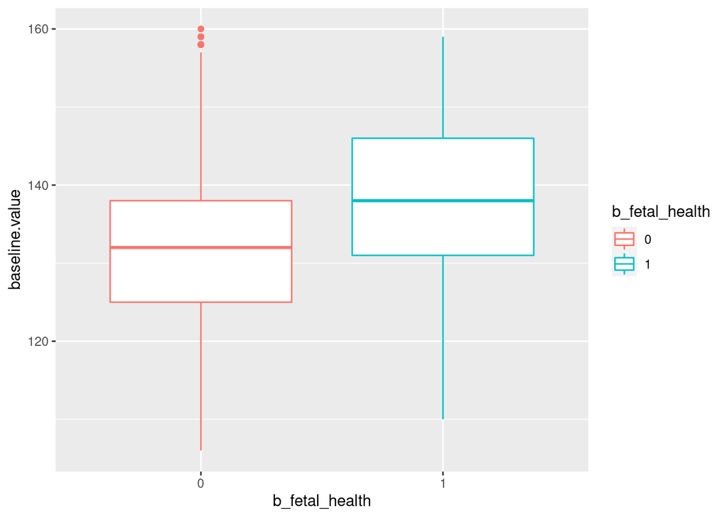

```r
g <- ggplot(fetal_health)
g + geom_boxplot(aes(x=b_fetal_health, y=baseline.value, colour=b_fetal_health))
```

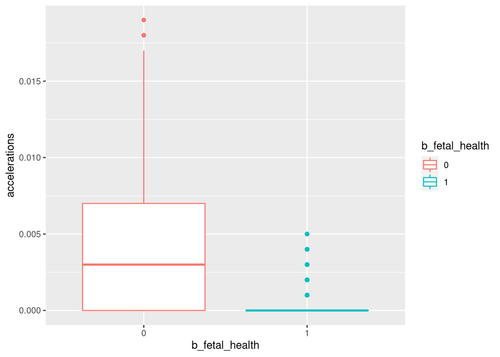

```r
g + geom_boxplot(aes(x=b_fetal_health, y=accelerations, colour=b_fetal_health))
```

Add more code chunks as needed…

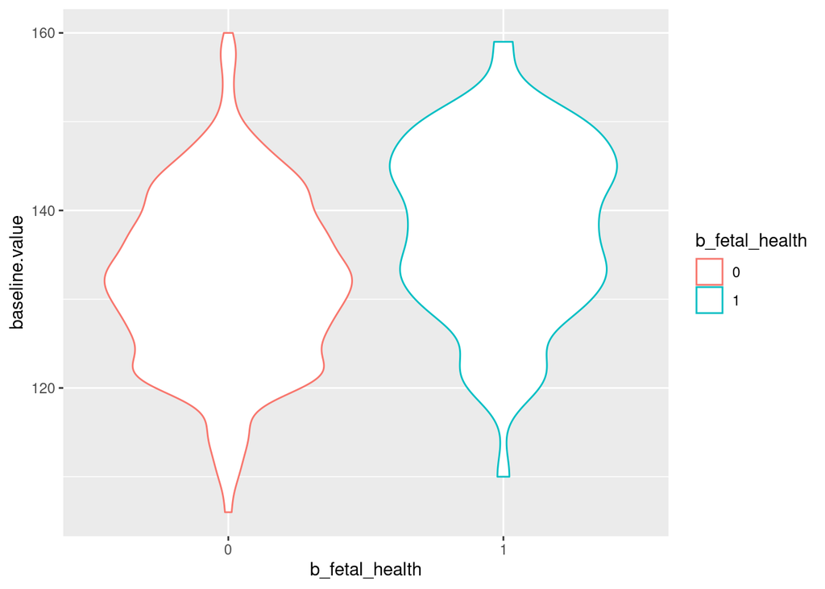

```r
g + geom_violin(aes(x=b_fetal_health, y=baseline.value, colour=b_fetal_health))
```

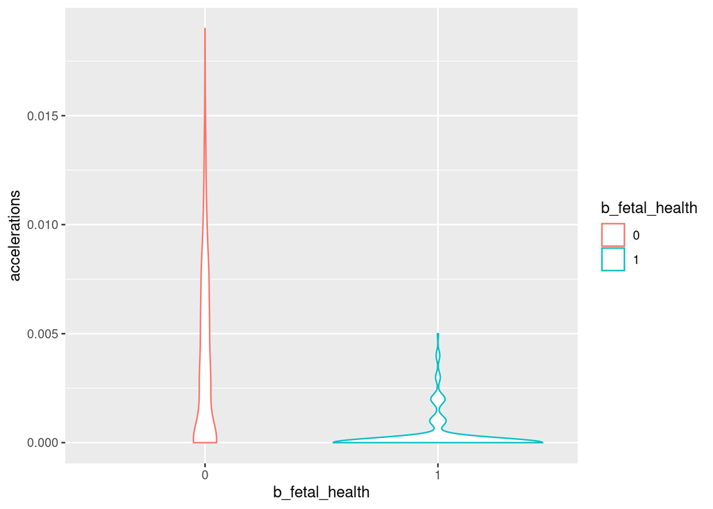

```r
g + geom_violin(aes(x=b_fetal_health, y=accelerations, colour=b_fetal_health))
```

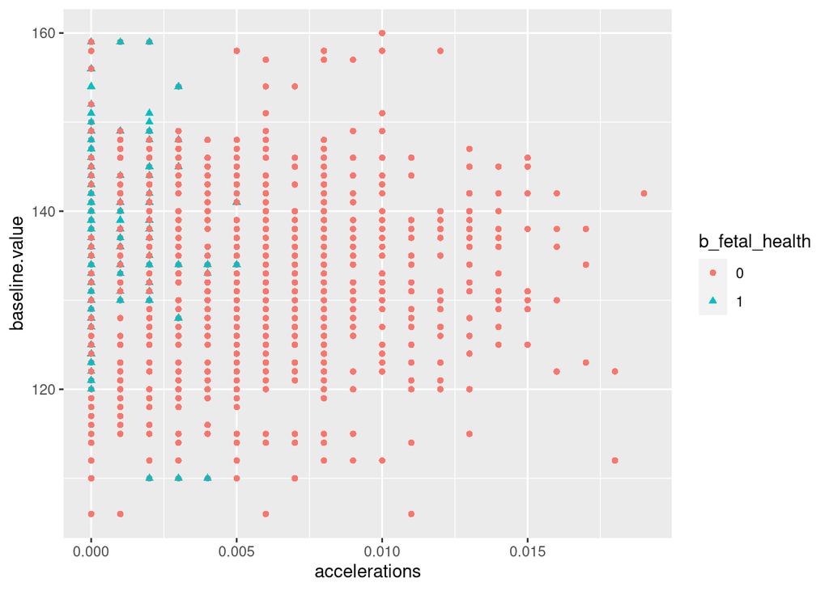

```r
g + geom_point(aes(x=accelerations, y=baseline.value, colour=b_fetal_health, shape=b_fetal_health))
```

## Step 4 - Partition into training and test sets

We will use the [caret](https://topepo.github.io/caret/) package to do the partitioning of our data into training and test dataframes. Just run this chunk to create training and test datasets. This way we’ll all be working with the same datasets. Notice that the test set is 20% of the full dataset.

```r
# Simple partition into train (80%) and test (20%) set
set.seed(17) # Do NOT change this
trainIndex <- createDataPartition(fetal_health$b_fetal_health, p = .8,
                                  list = FALSE,
                                  times = 1)

fh_train <- fetal_health[as.vector(trainIndex), ]
fh_test <- fetal_health[-as.vector(trainIndex), ]
```

Let’s do a quick check of the the target variable.

```r
table(fh_train$b_fetal_health)
```

```
##
##    0    1
## 1324  377
```

```r
prop.table(table(fh_train$b_fetal_health))
```

```
##
##         0         1
## 0.7783657 0.2216343
```

```r
table(fh_test$b_fetal_health)
```

```
##
##   0   1
## 331  94
```

```r
prop.table(table(fh_test$b_fetal_health))
```

```
##
##         0         1
## 0.7788235 0.2211765
```

## Step 5 - Building and evaluation of predictive classification models

Now that you know a little more about the data, it’s time to start building a few classification models for `b_fetal_health`. We will start out using overall prediction accuracy as our metric but we might want to consider other metrics.

**QUESTION** Why might overall prediction accuracy not be the most appropriate metric to consider? What other metrics might be important and why?

> Overall prediction accuracy might not be the most appropriate metric because the accuracy of a model is dependent on the significance of the classifier to the subject. For example, patients with normal fetal health assessment make up 78% of all patients. From this, it can be noted that a model that easily defaults to ‘0’ or a model that predicts ‘0’ for all patients will be considered 78% accurate. However, all 471 patients with suspect or pathological fetal health assessment will be wrongly assessed. The Sensitivity Measure for such model can be important to determine how many ‘1’s’ (suspect or pathological fetal health) were predicted correctly.

### Fit a null model

A very simple model would be to simply predict that `b_fetal_health` is equal to 0. On the training data we saw that we’d be ~78% accurate.

Let’s create this null model and run a confusion matrix on its “predictions” for both the training and the test data.

```r
# Create a vector of 0's
model_train_null <- rep(0, nrow(fh_train))
model_test_null <- rep(0, nrow(fh_test))

cm_train_null <- caret::confusionMatrix(as.factor(model_train_null), fh_train$b_fetal_health, positive="1")
cm_train_null
```

```
## Confusion Matrix and Statistics
##
##           Reference
## Prediction    0    1
##          0 1324  377
##          1    0    0
##
##                Accuracy : 0.7784
##                  95% CI : (0.7579, 0.7979)
##     No Information Rate : 0.7784
##     P-Value [Acc > NIR] : 0.5138
##
##                   Kappa : 0
##
##  Mcnemar's Test P-Value : <2e-16
##
##             Sensitivity : 0.0000
##             Specificity : 1.0000
##          Pos Pred Value :    NaN
##          Neg Pred Value : 0.7784
##              Prevalence : 0.2216
##          Detection Rate : 0.0000
##    Detection Prevalence : 0.0000
##       Balanced Accuracy : 0.5000
##
##        'Positive' Class : 1
##
```

```r
cm_test_null <- caret::confusionMatrix(as.factor(model_test_null), fh_test$b_fetal_health, positive="1")
cm_test_null
```

```
## Confusion Matrix and Statistics
##
##           Reference
## Prediction   0   1
##          0 331  94
##          1   0   0
##
##                Accuracy : 0.7788
##                  95% CI : (0.7363, 0.8174)
##     No Information Rate : 0.7788
##     P-Value [Acc > NIR] : 0.5276
##
##                   Kappa : 0
##
##  Mcnemar's Test P-Value : <2e-16
##
##             Sensitivity : 0.0000
##             Specificity : 1.0000
##          Pos Pred Value :    NaN
##          Neg Pred Value : 0.7788
##              Prevalence : 0.2212
##          Detection Rate : 0.0000
##    Detection Prevalence : 0.0000
##       Balanced Accuracy : 0.5000
##
##        'Positive' Class : 1
##
```

**QUESTION** A few questions:

- Are you surprised that the performance of the null model is almost identical on test and train? Why or why not?

> I am not surprised that the performance of the null model is almost identical on test and train because approximately 78% of the patients have “0” fetal health. So a model that defaults to “0” like the null model will have a similar accuracy. However, we can gain better insights on the performance of the model from the sensitivy measures. For both test and train, the null model has a sensitivity value of “0” because for all patients with a fetal health of “1”, the model predicted 0.
- Explain the sensitivity and specificity values. Why are they 0.0 and 1.0, respectively?

> The sensitivity value of 0.0 shows that for all patients with fetal health of “1”, the null model had a wrong prediction (“0”). While the specificity value of 1.0 shows that for all patients with fetal health of “0”, the null model had the right prediction.

So, as we begin fitting more complicated models, remember that we need to outperform the null model to make it worth it to use more complicated models.

Now I’m going to ask you to fit three models:

- a logistic regression model
- a simple decision tree
- a random forest

We covered all three of these modeling techniques in the class notes.

For each model type, you should:

- fit the model on the training data,
- assess the model’s performance on the training data using the `confusionMatrix` function,
- use the model to make predictions on the test data,
- assess the model’s performance on the test data using the `confusionMatrix` function,
- discuss the results

In your discussion of the results you should talk about things like:

- how accurate is the model in predicting on the test data
- is there evidence of overfitting?
- how does the model do in terms of other metrics like sensitivity and specificity
- other things you deem important.

### Fit logistic regression models

You’ll start by creating a logistic regression model to predict `b_fetal_health`. Since there are not that many variables, let’s use all of them. Here’s a code skeleton to help you get started:

**Hint**: There’s an easy way to specify your model formula to include all of the predictor variables without typing out all the variable names.

```r
# Fit model to training data
f <- as.formula(paste('b_fetal_health ~', paste(colnames(fetal_health)[1:21], collapse='+')))
model_lr1 <- glm(f, data=fh_train, family=binomial(link="logit"))

# Convert fitted model values to fitted classes
yhat_model_lr1 <- (model_lr1$fitted.values > 0.5) * 1
class_train_lr1 <- data.frame(as.factor(model_lr1$y),
                             as.factor(yhat_model_lr1))
names(class_train_lr1) <- c("yact","yhat")

cm_train_lr1 <- confusionMatrix(class_train_lr1$yhat, class_train_lr1$yact, positive="1")
cm_train_lr1
```

```
## Confusion Matrix and Statistics
##
##           Reference
## Prediction    0    1
##          0 1256   77
##          1   68  300
##
##                Accuracy : 0.9148
##                  95% CI : (0.9005, 0.9276)
##     No Information Rate : 0.7784
##     P-Value [Acc > NIR] : <2e-16
##
##                   Kappa : 0.7508
##
##  Mcnemar's Test P-Value : 0.5065
##
##             Sensitivity : 0.7958
##             Specificity : 0.9486
##          Pos Pred Value : 0.8152
##          Neg Pred Value : 0.9422
##              Prevalence : 0.2216
##          Detection Rate : 0.1764
##    Detection Prevalence : 0.2163
##       Balanced Accuracy : 0.8722
##
##        'Positive' Class : 1
##
```

Now, let’s predict on test data.

```r
pred_lr1 <- predict(model_lr1, newdata = fh_test, type = "response")
yhat_pred_lr1 <- (pred_lr1 > 0.5) * 1
class_test_lr1 <- data.frame(fh_test$b_fetal_health, as.factor(yhat_pred_lr1))
names(class_test_lr1) <- c("yact","yhat")

cm_test_lr1 <- confusionMatrix(class_test_lr1$yhat, class_test_lr1$yact, positive="1")
cm_test_lr1
```

```
## Confusion Matrix and Statistics
##
##           Reference
## Prediction   0   1
##          0 313  28
##          1  18  66
##
##                Accuracy : 0.8918
##                  95% CI : (0.8583, 0.9197)
##     No Information Rate : 0.7788
##     P-Value [Acc > NIR] : 1.04e-09
##
##                   Kappa : 0.6734
##
##  Mcnemar's Test P-Value : 0.1845
##
##             Sensitivity : 0.7021
##             Specificity : 0.9456
##          Pos Pred Value : 0.7857
##          Neg Pred Value : 0.9179
##              Prevalence : 0.2212
##          Detection Rate : 0.1553
##    Detection Prevalence : 0.1976
##       Balanced Accuracy : 0.8239
##
##        'Positive' Class : 1
##
```

**QUESTION** How did accuracy, sensitivity and specificity change when predicting on test data instead of the training data?

> The accuracy decreased from 91% on the trianing data to 89% on the test data. The sensitivity decreased from 79% on the training data to 70% on the test data, and with 94.86% on the training data and 94.56% on the test data, the specificity value was fairly constant.

Now try to increase the sensitivity of the model without significantly changing the specificity (hopefully).

```r
pred_lr1_v2 <- predict(model_lr1, newdata = fh_test, type = "response")
yhat_pred_lr1_v2 <- (pred_lr1_v2 > 0.35) * 1
class_test_lr1_v2 <- data.frame(fh_test$b_fetal_health, as.factor(yhat_pred_lr1_v2))
names(class_test_lr1_v2) <- c("yact","yhat")

cm_test_lr1_v2 <- confusionMatrix(class_test_lr1_v2$yhat, class_test_lr1_v2$yact, positive="1")

sprintf("Sensitivity: initial = %.3f version 2 = %.3f",cm_test_lr1$byClass["Sensitivity"],cm_test_lr1_v2$byClass["Sensitivity"])
```

```
## [1] "Sensitivity: initial = 0.702 version 2 = 0.819"
```

```r
sprintf("Specificity: initial = %.3f version 2 = %.3f",cm_test_lr1$byClass["Specificity"],cm_test_lr1_v2$byClass["Specificity"])
```

```
## [1] "Specificity: initial = 0.946 version 2 = 0.927"
```

**HACKER EXTRA** Create a double density plot to explore the impact of the threshold value on the predictions.

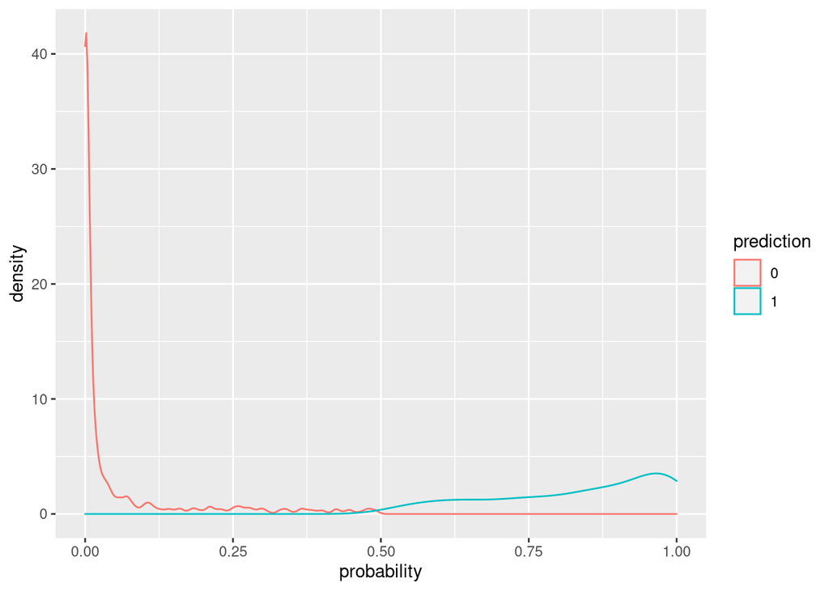

```r
double_density_df <- data.frame(probability = model_lr1$fitted.values, prediction = class_train_lr1$yhat)

ggplot(data = double_density_df, aes(x = probability, colour = prediction)) + geom_density()
```

## Fit simple decision tree model

Now create a simple decision tree model to predict `b_fetal_health`. Again, use all the variables.

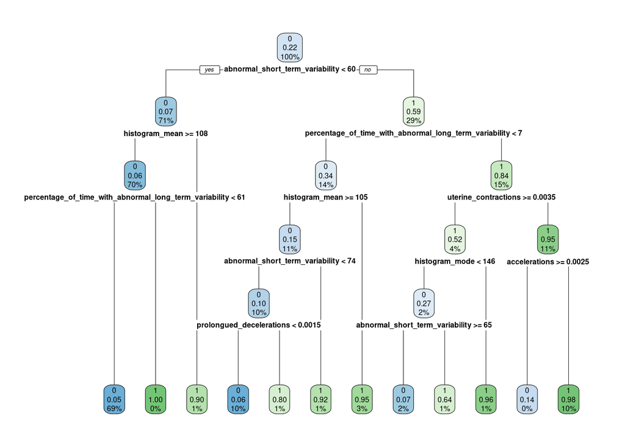

```r
model_tree1 <- rpart(f, data=fh_train)
rpart.plot(model_tree1)
```

```r
class_train_tree1 <- predict(model_tree1, type="class")

cm_train_tree1 <- confusionMatrix(class_train_tree1, fh_train$b_fetal_health, positive="1")
cm_train_tree1
```

```
## Confusion Matrix and Statistics
##
##           Reference
## Prediction    0    1
##          0 1307   71
##          1   17  306
##
##                Accuracy : 0.9483
##                  95% CI : (0.9366, 0.9583)
##     No Information Rate : 0.7784
##     P-Value [Acc > NIR] : < 2.2e-16
##
##                   Kappa : 0.842
##
##  Mcnemar's Test P-Value : 1.606e-08
##
##             Sensitivity : 0.8117
##             Specificity : 0.9872
##          Pos Pred Value : 0.9474
##          Neg Pred Value : 0.9485
##              Prevalence : 0.2216
##          Detection Rate : 0.1799
##    Detection Prevalence : 0.1899
##       Balanced Accuracy : 0.8994
##
##        'Positive' Class : 1
##
```

Now, let’s predict on test data.

```r
pred_tree1 <- predict(model_tree1, newdata = fh_test, type = "class")

cm_test_tree1 <- confusionMatrix(pred_tree1, fh_test$b_fetal_health, positive="1")
cm_test_tree1
```

```
## Confusion Matrix and Statistics
##
##           Reference
## Prediction   0   1
##          0 322  24
##          1   9  70
##
##                Accuracy : 0.9224
##                  95% CI : (0.8927, 0.946)
##     No Information Rate : 0.7788
##     P-Value [Acc > NIR] : 1.639e-15
##
##                   Kappa : 0.761
##
##  Mcnemar's Test P-Value : 0.01481
##
##             Sensitivity : 0.7447
##             Specificity : 0.9728
##          Pos Pred Value : 0.8861
##          Neg Pred Value : 0.9306
##              Prevalence : 0.2212
##          Detection Rate : 0.1647
##    Detection Prevalence : 0.1859
##       Balanced Accuracy : 0.8587
##
##        'Positive' Class : 1
##
```

**QUESTION** How does the performance of the decision tree compare to your logistic regression model?

```r
#LR and DT Accuracy on train and test data sets
sprintf("Accuracy on Training Data: Logistic Regression = %.3f Decision Trees = %.3f",cm_train_lr1$overall["Accuracy"],cm_train_tree1$overall["Accuracy"])
```

```
## [1] "Accuracy on Training Data: Logistic Regression = 0.915 Decision Trees = 0.948"
```

```r
sprintf("Accuracy on Test Data: Logistic Regression = %.3f Decision Trees = %.3f",cm_test_lr1$overall["Accuracy"],cm_test_tree1$overall["Accuracy"])
```

```
## [1] "Accuracy on Test Data: Logistic Regression = 0.892 Decision Trees = 0.922"
```

```r
#LR and DT Sensitivity on train and test data sets
sprintf("Sensitivity on Training Data: Logistic Regression = %.3f Decision Trees = %.3f",cm_train_lr1$byClass["Sensitivity"],cm_train_tree1$byClass["Sensitivity"])
```

```
## [1] "Sensitivity on Training Data: Logistic Regression = 0.796 Decision Trees = 0.812"
```

```r
sprintf("Sensitivity on Test Data: Logistic Regression = %.3f Decision Trees = %.3f",cm_test_lr1$byClass["Sensitivity"],cm_test_tree1$byClass["Sensitivity"])
```

```
## [1] "Sensitivity on Test Data: Logistic Regression = 0.702 Decision Trees = 0.745"
```

```r
#LR and DT Specificity on train and test data sets
sprintf("Specificity on Training Data: Logistic Regression = %.3f Decision Trees = %.3f",cm_train_lr1$byClass["Specificity"],cm_train_tree1$byClass["Specificity"])
```

```
## [1] "Specificity on Training Data: Logistic Regression = 0.949 Decision Trees = 0.987"
```

```r
sprintf("Specificity on Test Data: Logistic Regression = %.3f Decision Trees = %.3f",cm_test_lr1$byClass["Specificity"],cm_test_tree1$byClass["Specificity"])
```

```
## [1] "Specificity on Test Data: Logistic Regression = 0.946 Decision Trees = 0.973"
```

> With higher Accuracy, Sensitivity and Specificity values for both training and test data sets, the decision tree performed better than the logistic regression model.

## Fit random forest model

Finally, fit a random forest model.

```r
model_randforest1 <- randomForest(f, data=fh_train, mtry=7, importance=TRUE, na.action = na.omit)
model_randforest1
```

```
##
## Call:
##  randomForest(formula = f, data = fh_train, mtry = 7, importance = TRUE,      na.action = na.omit)
##                Type of random forest: classification
##                      Number of trees: 500
## No. of variables tried at each split: 7
##
##         OOB estimate of  error rate: 4.35%
## Confusion matrix:
##      0   1 class.error
## 0 1300  24  0.01812689
## 1   50 327  0.13262599
```

Now, let’s predict on test data.

```r
pred_randforest1 <- predict(model_randforest1, fh_test, type = "class")
cm_test_randforest1 <- confusionMatrix(pred_randforest1, fh_test$b_fetal_health, positive="1")
cm_test_randforest1
```

```
## Confusion Matrix and Statistics
##
##           Reference
## Prediction   0   1
##          0 326  12
##          1   5  82
##
##                Accuracy : 0.96
##                  95% CI : (0.9367, 0.9765)
##     No Information Rate : 0.7788
##     P-Value [Acc > NIR] : <2e-16
##
##                   Kappa : 0.8807
##
##  Mcnemar's Test P-Value : 0.1456
##
##             Sensitivity : 0.8723
##             Specificity : 0.9849
##          Pos Pred Value : 0.9425
##          Neg Pred Value : 0.9645
##              Prevalence : 0.2212
##          Detection Rate : 0.1929
##    Detection Prevalence : 0.2047
##       Balanced Accuracy : 0.9286
##
##        'Positive' Class : 1
##
```

**QUESTION** Summarize the performance of all three of your models (logistic, tree, random forest)? If you had to pick one to use in an actual clinical environment, which model would you use and why?

```r
#LR DT & RF Accuracy on test data sets
sprintf("Accuracy on Test Data: Logistic Regression = %.3f Decision Trees = %.3f Random Forest = %.3f",cm_test_lr1$overall["Accuracy"],cm_test_tree1$overall["Accuracy"],cm_test_randforest1$overall["Accuracy"])
```

```
## [1] "Accuracy on Test Data: Logistic Regression = 0.892 Decision Trees = 0.922 Random Forest = 0.960"
```

```r
#LR DT & RF Sensitivity on test data sets
sprintf("Sensitivity on Test Data: Logistic Regression = %.3f Decision Trees = %.3f Random Forest = %.3f",cm_test_lr1$byClass["Sensitivity"],cm_test_tree1$byClass["Sensitivity"],cm_test_randforest1$byClass["Sensitivity"])
```

```
## [1] "Sensitivity on Test Data: Logistic Regression = 0.702 Decision Trees = 0.745 Random Forest = 0.872"
```

```r
#LR DT & RF Specificity on test data sets
sprintf("Specificity on Test Data: Logistic Regression = %.3f Decision Trees = %.3f Random Forest = %.3f",cm_test_lr1$byClass["Specificity"],cm_test_tree1$byClass["Specificity"],cm_test_randforest1$byClass["Specificity"])
```

```
## [1] "Specificity on Test Data: Logistic Regression = 0.946 Decision Trees = 0.973 Random Forest = 0.985"
```

> With the highest Accuracy, Sensitivity and Specificity values on the test data set, the random forest model performed best among the 3 models. In a clinical environment, my choice would be the random forest because of the accuracy and sensitivity values. It is paramount that a model is able to identify patients with suspect or pathological fetal health. If a patient is wrongly assessed as suspect or pathological, then further tests can help verify and correct the assessment. However, patients with suspect or pathological fetal health that are wrongly predicted to be normal might not undergo further tests.

**HACKER EXTRA**

Create a variable importance plot for your random forest to try to get a sense of which variables are most important in predicting fetal health. Build another random forest using only the top 5 or so variables suggested by the importance plot. How does the performance of this reduced model compare to the original model?

```r
df_imp <- as.data.frame(model_randforest1$importance) %>%
  arrange(desc(MeanDecreaseGini))

df_imp <- tibble::rownames_to_column(df_imp, "variable")
df_imp
```

```
##                                                  variable            0
## 1                         abnormal_short_term_variability 0.0326812086
## 2                    mean_value_of_short_term_variability 0.0260438130
## 3  percentage_of_time_with_abnormal_long_term_variability 0.0386818839
## 4                                          histogram_mean 0.0330866072
## 5                                           accelerations 0.0294605710
## 6                                          histogram_mode 0.0198710987
## 7                                    uterine_contractions 0.0068811378
## 8                                prolongued_decelerations 0.0078068261
## 9                                        histogram_median 0.0181331558
## 10                                          histogram_min 0.0162523074
## 11                    mean_value_of_long_term_variability 0.0067474569
## 12                                         baseline.value 0.0198716025
## 13                                        histogram_width 0.0111778835
## 14                                     histogram_variance 0.0086642659
```

[output cut: 29 more lines]

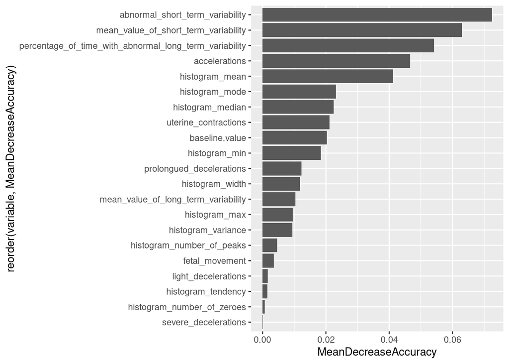

```r
ggplot(data = df_imp) + geom_bar(aes(x=reorder(variable, MeanDecreaseAccuracy), y=MeanDecreaseAccuracy), stat = "identity") + coord_flip()
```

```r
model_randforest2 <- randomForest(b_fetal_health ~ abnormal_short_term_variability+ mean_value_of_short_term_variability+percentage_of_time_with_abnormal_long_term_variability+accelerations+histogram_mean, data=fh_train, importance=TRUE, na.action = na.omit)

model_randforest2
```

```
##
## Call:
##  randomForest(formula = b_fetal_health ~ abnormal_short_term_variability +      mean_value_of_short_term_variability + percentage_of_time_with_abnormal_long_term_variability +      accelerations + histogram_mean, data = fh_train, importance = TRUE,      na.action = na.omit)
##                Type of random forest: classification
##                      Number of trees: 500
## No. of variables tried at each split: 2
##
##         OOB estimate of  error rate: 5.53%
## Confusion matrix:
##      0   1 class.error
## 0 1288  36  0.02719033
## 1   58 319  0.15384615
```

```r
pred_randforest2 <- predict(model_randforest2, fh_test, type = "class")
cm_test_randforest2 <- confusionMatrix(pred_randforest2, fh_test$b_fetal_health, positive="1")
cm_test_randforest2
```

```
## Confusion Matrix and Statistics
##
##           Reference
## Prediction   0   1
##          0 321  16
##          1  10  78
##
##                Accuracy : 0.9388
##                  95% CI : (0.9116, 0.9597)
##     No Information Rate : 0.7788
##     P-Value [Acc > NIR] : <2e-16
##
##                   Kappa : 0.8183
##
##  Mcnemar's Test P-Value : 0.3268
##
##             Sensitivity : 0.8298
##             Specificity : 0.9698
##          Pos Pred Value : 0.8864
##          Neg Pred Value : 0.9525
##              Prevalence : 0.2212
##          Detection Rate : 0.1835
##    Detection Prevalence : 0.2071
##       Balanced Accuracy : 0.8998
##
##        'Positive' Class : 1
##
```

```r
#RF Accuracy on test data sets
sprintf("Accuracy on Test Data: Model 1 = %.3f Model 2 = %.3f",cm_test_randforest1$overall["Accuracy"],cm_test_randforest2$overall["Accuracy"])
```

```
## [1] "Accuracy on Test Data: Model 1 = 0.960 Model 2 = 0.939"
```

```r
#RF Sensitivity on test data sets
sprintf("Sensitivity on Test Data: Model 1 = %.3f Model 2 = %.3f",cm_test_randforest1$byClass["Sensitivity"],cm_test_randforest2$byClass["Sensitivity"])
```

```
## [1] "Sensitivity on Test Data: Model 1 = 0.872 Model 2 = 0.830"
```

```r
#RF Specificity on test data sets
sprintf("Specificity on Test Data: Model 1 = %.3f Model 2 = %.3f",cm_test_randforest1$byClass["Specificity"],cm_test_randforest2$byClass["Specificity"])
```

```
## [1] "Specificity on Test Data: Model 1 = 0.985 Model 2 = 0.970"
```